# compile-regional-data

### 2.2.8 West VI

In the 2025 State of Salmon report, we have split the former “Vancouver Island & Mainland Inlets” region into two: East Vancouver Island & Mainland Inlets and West Vancouver Island. This split was made to better reflect the different ecology and habitats of salmon between the regions that may lead to different status and trends.

#### Chinook

For Chinook spawner abundance, we used the West Coast Vancouver Island (WCVI) 14-stream index escapements of Pacific Salmon Commission Chinook Technical Committee wild Chinook salmon escapement indicator stocks, available in Appendix B5 of Chinook Technical Committee (2025) Streams were selected to represent WVI Chinook populations “with little or no hatchery influence” (Chinook Technical Committee 2025). **We truncated this time series to only include years from 1995 onwards, because earlier escapement estimates used different methodology and have not been calibrated (Chinook Technical Committee 2025).** Chinook total abundance was recently reported bg DFO (DFO 2025). The data shown in Figure 3 of DFO (2025) are available for download at https://zenodo.org/records/14847020 [accessed 25-Aug-2025]. We assumed that total abundance is the sum of the (non-terminal) ocean catch, hatchery-origin terminal return, and natural-origin terminal return. We note that this estimate of total abundance represents a total count of all Chinook from the region, and thus cannot be compared to the index of spawner abundance, which represents only a proportion of those fish.

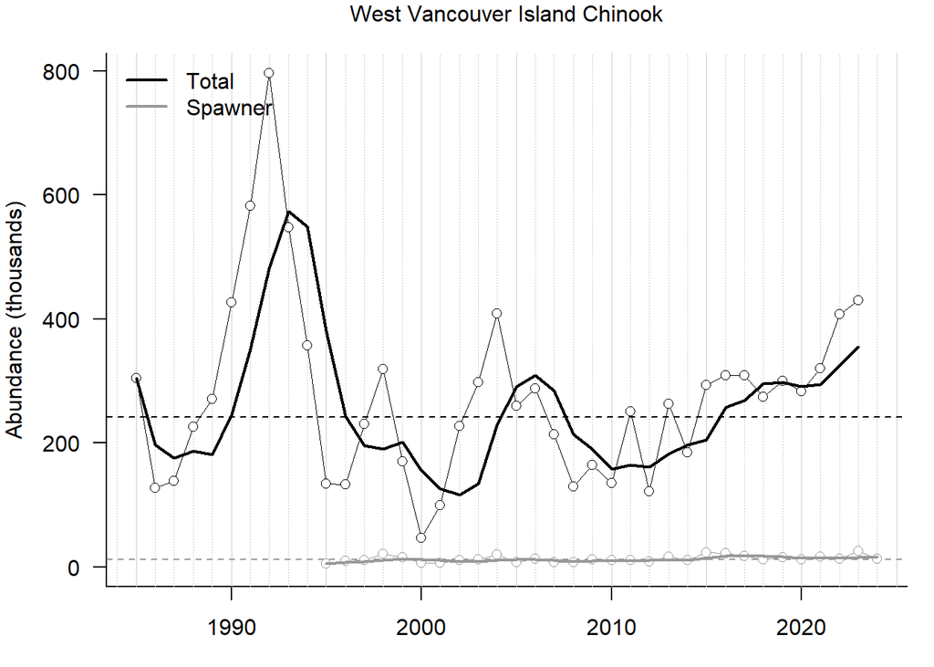

**Above:**Spawner abundance (grey) and total abundance (black) of West Vancouver Island chinook salmon. For both, the raw data is shown by points and the smoothed metric by solid lines. Dashed horizonal lines represent the long-term average for each.

```r
## Load data ---
wvi_ck_raw <- readxl::read_xlsx("../data/TCCHINOOK-25-02-Appendix-B-Escapement-Detailed.xlsx", sheet = "B5", range = "K24:K53", col_names = "WCVI_14Stream_Index") %>%
    mutate(Year = c(1995:2024))
# Escapement methods changed in 1995; only use earlier data for assessments

# West Vancouver Island from Brown et al. 2025
wvi_ck_tot_raw <- read_xlsx("../data/WCVI_Chinook_total_abundance.xlsx")

wvi_ck_tot_raw$total_abundance <-  wvi_ck_tot_raw$`Hatchery origin Terminal Return` + wvi_ck_tot_raw$`Natural origin Terminal Return` +  wvi_ck_tot_raw$`non-terminal Ocean catch`

yrs <- sort(unique(c(wvi_ck_tot_raw$`Return year`, wvi_ck_raw$Year)))

# Put in SPS format
wvick_sps <- data.frame(
    region = rep("West Vancouver Island", length(yrs)),
    species = rep("Chinook", length(yrs)),
    year = yrs,
    spawners = wvi_ck_raw$WCVI_14Stream_Index[match(yrs, wvi_ck_raw$Year)],
    smoothedSpawners = NA,
    runsize = wvi_ck_tot_raw$total_abundance[match(yrs, wvi_ck_tot_raw$`Return year`)],
    smoothedRunsize = NA,
    source_id = rep(paste(ctc_id, "Brown_20250703", sep = ", "), length(yrs))
)

# Smoothing
wvick_sps$smoothedSpawners <- genSmooth(
    abund = wvick_sps$spawners,
    years = wvick_sps$year,
    genLength = genLength$gen_length[genLength$region == "West Vancouver Island" & genLength$species == "Chinook"]
)

wvick_sps$smoothedRunsize <- genSmooth(
    abund = wvick_sps$runsize,
    years = wvick_sps$year,
    genLength = genLength$gen_length[genLength$region == "West Vancouver Island" & genLength$species == "Chinook"]
)


if(1 == 2){
    avg <- c(spawners = exp(mean(log(wvick_sps$spawners), na.rm = TRUE)),
    total = exp(mean(log(wvick_sps$runsize), na.rm = TRUE)))

    plot(wvick_sps$year, (wvick_sps$smoothedRunsize - avg[2])/avg[2], "o", pch = 19)
    abline(h= avg[2])
    points(wvick_sps$year, (wvick_sps$smoothedSpawners - avg[1])/avg[1], "o", col = grey(0.6))

}
# Add to master sps dataframe
sps_data <- rbind(sps_data, wvick_sps)

# Generate standard plot
plot_abund(wvick_sps)
```

#### Sockeye

Reconstructions of sockeye spawners and recruitment are compelted by DFO (Nicholas Brown, pers. comm.) for three Conservation Units on West Vancouver Island: Sproat, Great Central, and Hucuktlis (formerly Henderson). We used the sum of spawners and total return for these three Conservation Units as the index of sockeye spawner and total abundance for WVI. We acknowledge that this index does not account for lake-type sockeye in other watersheds (e.g., Muchalat, Kennedy, Clayoquot) or river-type sockeye in West Vancouver Island and Northwest Vancouver Island CUs, which tend to be in much lower abundance.

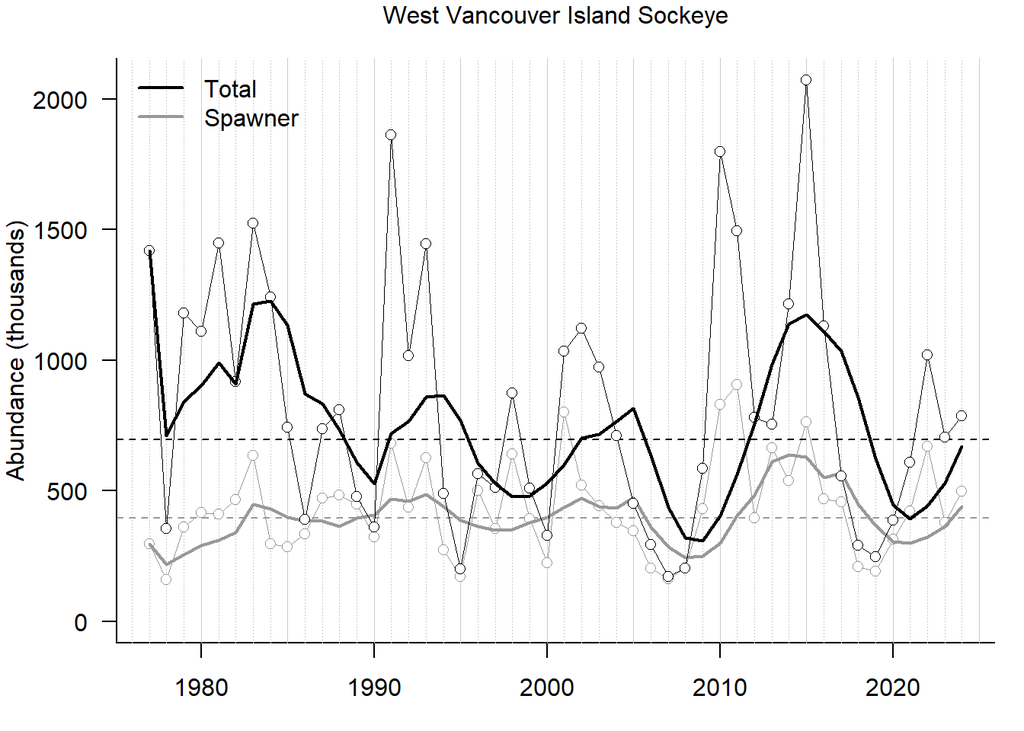

**Above:**Spawner abundance (grey) and total abundance (black) of West Vancouver Island sockeye salmon. For both, the raw data is shown by points and the smoothed metric by solid lines. Dashed horizonal lines represent the long-term average for each.

```r
# Sum of CU abundance from Sproat, Great Central, and Henderson
## Load data ---
wvi_se_raw <- readxl::read_xlsx("../data/Barkley_Sockeye_stock-recruit_infilled.xlsx", sheet = "S-R data")

wvi_se_summed <- wvi_se_raw %>%
    dplyr::select(year, stock, S, N) %>% # S = escapement, N = annual terminal run size
    filter(year >= 1977) %>% # Remove 1972 to 2076 for HUC because not available for other stocks
    group_by(year) %>%
    summarise(totalS = sum(S),
                        totalN = sum(N))

# plot(wvi_se_summed$year, wvi_se_summed$totalN, "o", ylim = c(0, 2e6), main = "WVI Sockeye", xlab = "", ylab = "")
# points(wvi_se_summed$year, wvi_se_summed$totalS, "o",  col = 2)
# points(yrs, sp[2, "Sockeye", ], "o", col = 4)
# legend("topleft", col = c(1,2,4), c("3 CU - Total run", "3 CU - Escape.", "NuSEDS expanded"), pch = 1, lty = 1)

# Reformat data for SPS
wvise_sps <- data.frame(
    region = rep("West Vancouver Island", dim(wvi_se_summed)[1]),
    species = rep("Sockeye", dim(wvi_se_summed)[1]),
    year = wvi_se_summed$year,
    spawners = wvi_se_summed$totalS,
    smoothedSpawners = NA,
    runsize = wvi_se_summed$totalN,
    smoothedRunsize = NA,
    source_id = rep("Brown_20250417", dim(wvi_se_summed)[1])
)

# Smoothing
wvise_sps$smoothedSpawners <- genSmooth(
    abund = wvise_sps$spawners,
    years = wvise_sps$year,
    genLength = genLength$gen_length[genLength$region == "West Vancouver Island" & genLength$species == "Sockeye"]
)

wvise_sps$smoothedRunsize <- genSmooth(
    abund = wvise_sps$runsize,
    years = wvise_sps$year,
    genLength = genLength$gen_length[genLength$region == "West Vancouver Island" & genLength$species == "Sockeye"]
)

# Add to master sps dataframe
sps_data <- rbind(sps_data, wvise_sps)

# Generate standard figure
plot_abund(wvise_sps)
```